# Missing Values

Pietro Franceschi | pietro.franceschi@fmach.it

## Missing Values

*In statistics, missing data, or missing values, occur when no data value is stored for the variable in an observation. Missing data are a common occurrence and can have a significant effect on the conclusions that can be drawn from the data.*

- Data can be missing **at random** or **not at random**
- In **metabolomics** missing values arise when, for a sample, it was not possible to get a specific intensity for a feature/metabolite

## Notes

In metabolomics missing values pop up for different reasons

1. There was an error during preprocessing (targeted or untargeted)
2. For a sample the concentration of a metabolite was really low
3. A metabolite was “absent” in a sample I’ll get a missing value (*eg. red pigment in a an extract of white grape*)

1,2 & 3 are **random** or **not random** ?

## Analytical Absence

[figure not shown]

Having a **Missing** is **not** equivalent of having **zero** concentration!

- Each analytical method is characterized by a well defined *detection limit*
- Every concentration between zero and the detection limit will not be detected
- We never can be 100% sure that something is absent from my sample …

Where can we get the detection limit ?

## Scenario 1: 1 class

Signal close to the detection limit

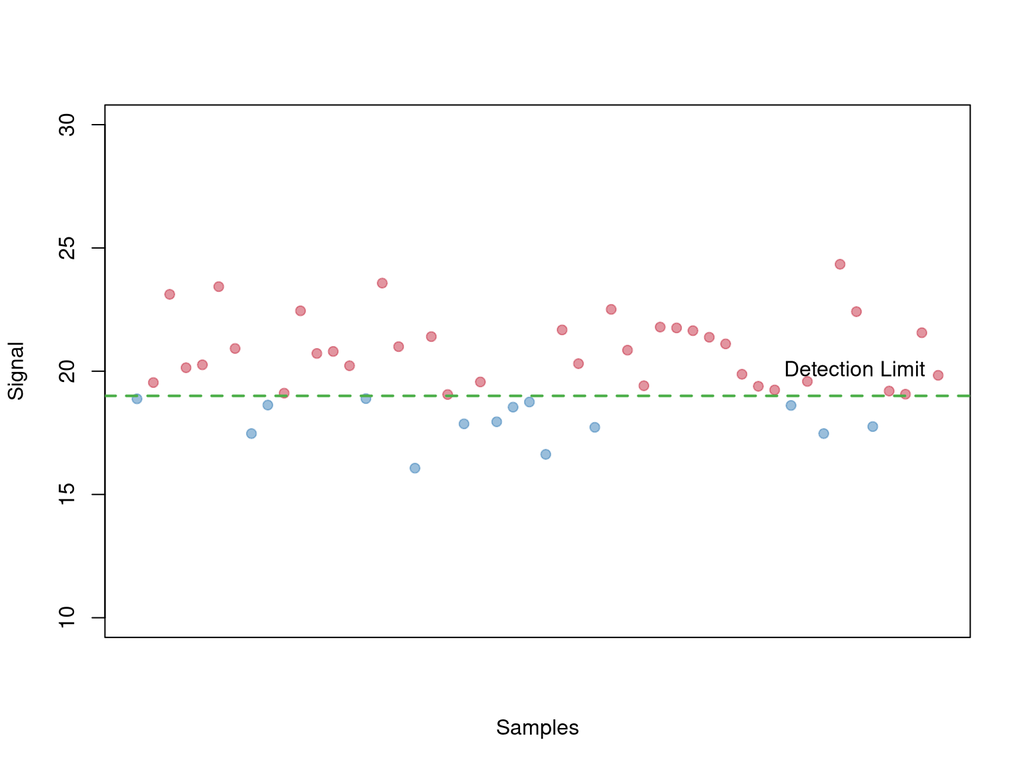

Missing values are “randomly” popping-up

## Scenario 2: 2 class biomarker

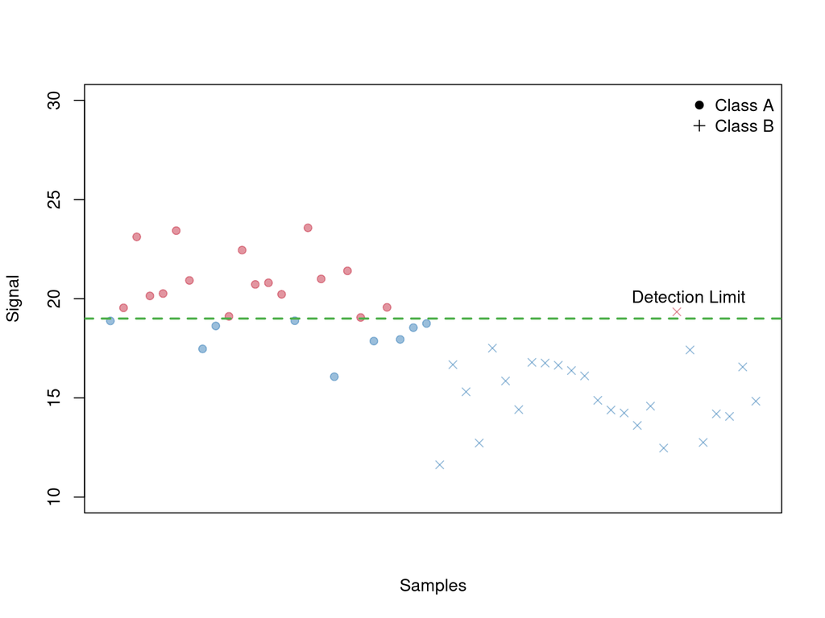

Missing values are not “randomly” popping-up

## Scenario 3: 2 class ??

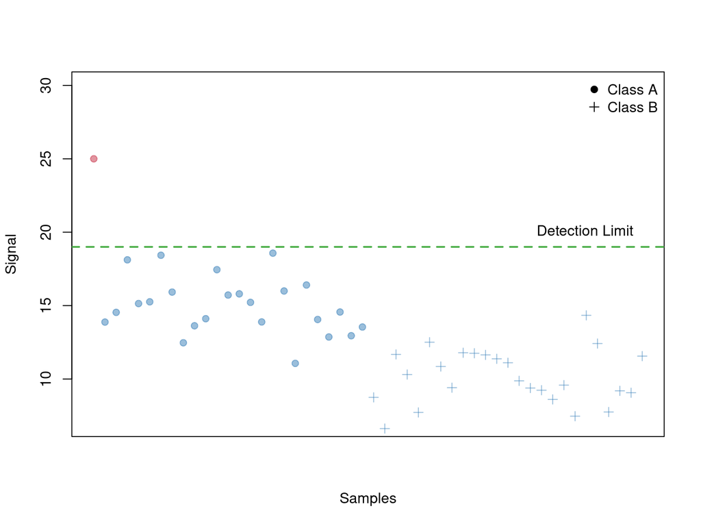

[figure not shown]

**What would you propose to do in the previous three cases?**

## Dealing with missing values

- Use statistical methods able to handle missing data
- Impute them put a reasonable number with variability
- Remove features with too many NAs (scenario 3)

How many NAs are acceptable **depends on the allocation of the samples to the factors of the study**

## Imputation

**Imputation** is the process of substituting a missing value with a reasonable number:

1. multivariate imputation uses the value of samples which are close in the multivariate space to select a good number (`missMDA` package, KNN imputation, … ). This works well if data are missing at random …
2. a reasonable number can be chosen on the bases of analytical considerations (e.g. a random number between zero and the detection limit)
3. the imputation strategy should be not “aware” of the design of the study

## Further Observations

- It is “easier” to handle missing values randomly distributed
- Use **domain specific knowledge** (e.g analytical - LOD) inject new knowledge in the data analysis pipeline!
- **Quality Check**: try different forms of imputation: are the outcomes sensitive to that?